# Colby R User Group

9.30.2021

### Colby R User Group

#### 9.30.2021

- What's new in R 4.1
  - The native pipe: `|>`
  - The lambda function : `\`
  - Color palettes
- Colby hosted web based R platforms
- General discussion

### Colby R User Group

#### 9.30.2021

- What's new in R 4.1
  - The native pipe: `|>`
  - The lambda function : `\`
  - Color palettes
- Colby hosted web based R platforms
- General discussion

### Why a pipe?

Verbose

```r
mtcars.sub <- subset(mtcars, select = mpg:hp)
summary(mtcars.sub)
```

Compact

```r
summary(subset(mtcars,select=mpg:hp))
```

Just right?

```r
mtcars %>%
  subset(select = mpg:hp) %>%
  summary()
```

### A bit of %>%'s background

The `%>%` pipe's origins stem from Stefan Milton Bache's `magrittr` package (now part of the tidyverse suite of packages)

```r
library(magrittr)
mtcars %>% subset(select = mpg:hp) %>% summary()
```

```
      mpg             cyl             disp             hp
 Min.   :10.40   Min.   :4.000   Min.   : 71.1   Min.   : 52.0
 1st Qu.:15.43   1st Qu.:4.000   1st Qu.:120.8   1st Qu.: 96.5
 Median :19.20   Median :6.000   Median :196.3   Median :123.0
 Mean   :20.09   Mean   :6.188   Mean   :230.7   Mean   :146.7
 3rd Qu.:22.80   3rd Qu.:8.000   3rd Qu.:326.0   3rd Qu.:180.0
 Max.   :33.90   Max.   :8.000   Max.   :472.0   Max.   :335.0
```

### Pipe was not native to R ... until now

The native pipe `|>`

```r
mtcars  |>
  subset(select = mpg:hp)  |>
  summary()
```

### Shortcut

Windows: `ctr + shift + M`

Mac: `cmd + shift + M`

[figure not shown]

### What does a pipe do exactly?

```r
mtcars |> subset(select= mpg:hp) |> head(10)
```

```
                   mpg cyl  disp  hp
Mazda RX4         21.0   6 160.0 110
Mazda RX4 Wag     21.0   6 160.0 110
Datsun 710        22.8   4 108.0  93
Hornet 4 Drive    21.4   6 258.0 110
Hornet Sportabout 18.7   8 360.0 175
Valiant           18.1   6 225.0 105
Duster 360        14.3   8 360.0 245
Merc 240D         24.4   4 146.7  62
Merc 230          22.8   4 140.8  95
Merc 280          19.2   6 167.6 123
```

### What does a pipe do exactly?

A pipe feeds the contents (or output) from the left hand side (LHS) into the first *unnamed* argument of the right hand side (RHS) function.

The `subset` function has the following arguments:

```
function (x, subset, select, drop = FALSE, ...)
```

The first argument is `x =` (the input dataframe)

### LHS is piped into 1st argument of RHS

The pipe passes the contents on the LHS to the first *unnamed* argument ( `x = ...`) of the RHS function.

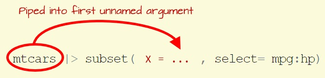

This is the same as writing:

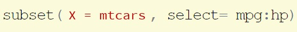

### LHS is piped into 1st unnamed argument of RHS

If the input argument is not the first argument, this will pose a problem to both methods. For example, the following command generates an error regardless of the choice of pipes.

```r
mtcars |> lm(hp ~ mpg )
```

```
Error in as.data.frame.default(data): cannot coerce class '"formula"' to a data.frame
```

### LHS is piped into 1st unnamed argument of RHS

If the input argument is not the first argument, this will pose a problem to both methods. For example, the following command generates an error regardless of the choice of pipes.

```r
mtcars |> lm(hp ~ mpg )
```

```
Error in as.data.frame.default(data): cannot coerce class '"formula"' to a data.frame
```

But if the first argument is named, the LHS gets fed to the second argument in `lm` which is `data = ...`

```r
mtcars |> lm(formula = hp ~ mpg)
```

```
Call:
lm(formula = hp ~ mpg, data = mtcars)

Coefficients:
(Intercept)          mpg
     324.08        -8.83
```

### LHS is piped into 1st unnamed argument of RHS

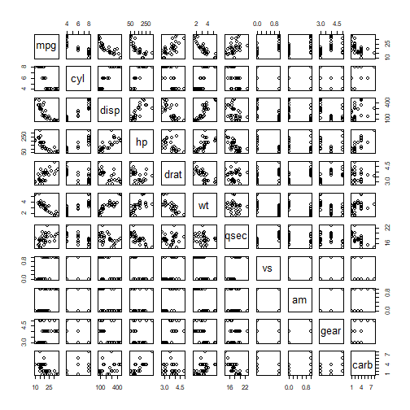

```r
mtcars |>  plot(formula = hp ~ mpg)
```

### %>% offers a placeholder "."

The `%>%` operator allows you to specify which argument the LHS is to be piped into.

```r
mtcars %>% lm(hp ~ mpg, data = .)
```

```
Call:
lm(formula = hp ~ mpg, data = .)

Coefficients:
(Intercept)          mpg
     324.08        -8.83
```

### |> requires an anonymous function

The native pipe does not recognize the `.` placeholder. Instead, you need to embed an *anonymous function*.

```r
mtcars |>  lm(formula = hp ~ mpg, data = .)
```

```
Error in is.data.frame(data): object '.' not found
```

### |> requires an anonymous function

The workaround is to embed an anonymous function.

```r
mtcars |>  (function(x)( lm(hp ~ mpg, x))) ()
```

```
Call:
lm(formula = hp ~ mpg, data = x)

Coefficients:
(Intercept)          mpg
     324.08        -8.83
```

### |> is faster than %>%

`sqrt(10)` vs. `10 |> sqrt()` vs `10 %>% sqrt()`

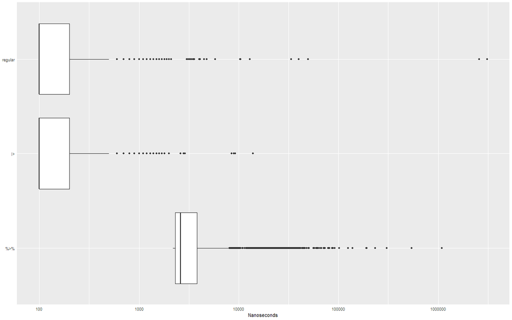

### The function shorthand: \()

R 4.1 introduces the `\()` shorthand for the `function()` function. This reduces code syntax.

For example, the following lines of code are interchangeable

```r
mtcars |>  ( function(x)  plot(hp ~ mpg, x)) ()
mtcars |>  (        \(x)  plot(hp ~ mpg, x)) ()
```

Another example:

```r
f1 <- function(x,y) x + y
f1 <-        \(x,y) x + y
f1(2,3)
```

```
[1] 5
```

### color palettes

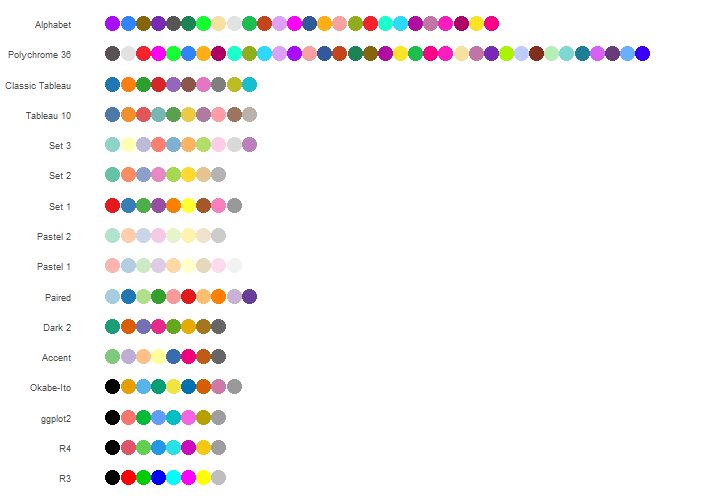

### color palettes

To list palettes

```r
palette.pals()
```

```
 [1] "R3"              "R4"              "ggplot2"         "Okabe-Ito"
 [5] "Accent"          "Dark 2"          "Paired"          "Pastel 1"
 [9] "Pastel 2"        "Set 1"           "Set 2"           "Set 3"
[13] "Tableau 10"      "Classic Tableau" "Polychrome 36"   "Alphabet"
```

To set palette

```r
palette("Pastel 1")
palette()
```

```
[1] "#FBB4AE" "#B3CDE3" "#CCEBC5" "#DECBE4" "#FED9A6" "#FFFFCC" "#E5D8BD"
[8] "#FDDAEC" "gray95"
```

### Colby R User Group

#### 9.30.2021

- What's new in R 4.1
  - The native pipe: `|>`
  - The lambda function : `\`
  - Color palettes
- Colby hosted web based R platforms -> Randy
- General discussion

### Colby R User Group

#### 9.30.2021

- What's new in R 4.1
  - The native pipe: `|>`
  - The lambda function : `\`
  - Color palettes
- Colby hosted web based R platforms -> Randy
- General discussion